# Topic Classifications

By *Ruosi Wang* 2019/2/11

## Data

The **features** were the *meetup group descriptions* and the **labels** were the respective *topics* of the groups. Here is an *example* of a *social* event and a *tech* event.

| Topic | Meetup Group Description |
| --- | --- |
| *scoial* | Our Groups is for LADIES ONLY and it's about making new friends. Many of us are new or fairly new to XXX and the XXXX and want to meet new people. This is NOT a networking group, it is a group to make… |
| *tech* | These meetings are a mixture of a complete geek-fest and helping newer Internet marketers get off the ground with questions as well.The sole purpose for these meetings is to share and gather experienc… |

There are in total of 102691 meetup group descriptions. The median length of the documents of descriptions is 393, with IQR as 463.

## Steps

1. **Text cleaning** was first conducted to remove stop words (e.g., meetup, member, group) and non-word characters (e.g., HTML tags, languages other than English).
2. **Training**

   We first split the dataset into a training set (80%) and a testing set (20%)

   **Machine learning models**: We first extracted the TFIDF (term frequency–inverse document frequency) with chi-square feature selection (top 10000 features). Then, we trained Multinomial Naïve Bayes Classifier (MNB) and Linear Support Vector Machine Classifier (SVC) with hyperparameter tuning with cross-validation (20%). We also tested Random Forest Classifier(RFC), and Etra Tree Classifier(ETC) models in the early stage, but they didn't perform very well.

   To benchmark the performance of these models, we chose the [*F1-score*](https://en.wikipedia.org/wiki/F1_score) as the metric, which combined both precision and recall rates and suited better for imbalanced datasets. We examined the classification F1-score on the top 5, 10, 15, and 20 topics with the most number of groups.

## Results

```python
%matplotlib inline
import viz_classification as vz
vz.plot_topic_classifications()
```

[interactive chart not shown]

The above figure shows the f1-scores of the tested models on 5, 10, 15, and 20 topic classifications.

- Classification rates decrease as the number of topics to classify increase,
- GRU and SVC displayed the highest f1-scores.
- Though MNB is a straightforward model, it performed not much worse than more complicated models and outperformed 1D CNN. One possible reason for this could be that the training sample is still not enough for Deep learning models to gain advantages.

## Confusion Matrix

```python
vz.plot_conf_matrix('GRU', 10)
```

[interactive chart not shown]

Here, we examined the confusion matrix of the top 10 topics (GRU model). The percents results were indicators of classifications. In all **off-diagonal** cells, the darker the cells, the higher the misclassification rates. The raw number is also shown when a mouse cursor moves over. Besides, the order of topics was sorted by the number of samples (groups) in each class, with *career-business* being the most and *parent-family* being the least.

- Several pairs of topics generated more errors, such as *career-business* and *tech*, *health-wellness* and *beliefs*, indicating closer relationships with them.
- The topic *tech* had the highest recall (89.7%); the topics of *social* and *movements* had the lowest recall (70.6%, 70.3%).

## Visualize Important features

Though both GRU and SVC have the best classification results, it is quite difficult to visualize these models or explain what the most important features are. In contrast, MNB is much easier for interpretations. Here are some examples of the critical features for different meetup topics from the MNB model.

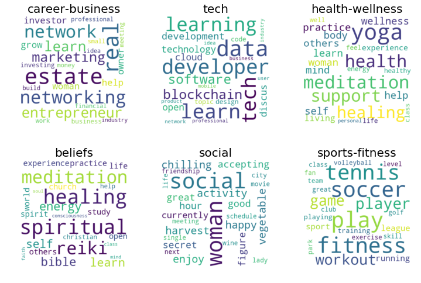

```python
vz.plot_word_cloud(topic_num=6)
```

#### Methods

The **dataset** was fetched from the [Meetup API](https://www.meetup.com/meetup_api/) utilizing a python [API client](https://pypi.org/project/meetup-api/). In particular, We first identified the Meetup groups(>100 members) in the top 30 US cities with the most number of groups and then gathered the meetup details associated with these groups between 2011 and 2018 July.

We implemented the above analysis with [sklearn](https://scikit-learn.org/) and [keras](https://keras.io/), please see [here](https://github.com/narrow-street/plan-your-meetup/blob/master/app/topic_classifier.py) for the source code.